# Лабораторная работа № 5

Задача об эпидемии

Анна Светцова

1132230807@pfur.ru

Российский университет дружбы народов

2026-10-08

# Информация

## Докладчик

**Анна Светцова**

Российский университет дружбы народов

1132230807@pfur.ru

# Вводная часть

## Актуальность

- Эпидемические модели позволяют исследовать динамику распространения инфекции
- Население разделяется на восприимчивых, инфицированных и людей с иммунитетом
- Критическое число заболевших определяет два качественно разных режима
- Параметры модели влияют на высоту и время эпидемического пика

## Цель работы

Исследовать эпидемическую модель для варианта 58:

- построить динамику групп $S(t)$, $I(t)$ и $R(t)$;
- сравнить случаи $I(0)\le I^*$ и $I(0)>I^*$;
- проверить сохранение общей численности;
- исследовать влияние коэффициента заболеваемости.

# Постановка задачи

## Исходные данные

Для варианта 58:

$$N=17854,$$

$$I(0)=199,\qquad R(0)=35,$$

$$S(0)=17620.$$

В вычислительном эксперименте:

$$\alpha=10^{-5},\qquad \beta=0.02.$$

## Группы населения

- $S(t)$ — восприимчивые к болезни;
- $I(t)$ — инфицированные;
- $R(t)$ — люди с иммунитетом.

Во всех режимах:

$$S(t)+I(t)+R(t)=N.$$

# Математическая модель

## Случай $I(0)\le I^*$

При изоляции заболевших новые заражения отсутствуют:

$$\frac{dS}{dt}=0,$$

$$\frac{dI}{dt}=-\beta I,$$

$$\frac{dR}{dt}=\beta I.$$

## Случай $I(0)>I^*$

При активном распространении:

$$\frac{dS}{dt}=-\alpha SI,$$

$$\frac{dI}{dt}=\alpha SI-\beta I,$$

$$\frac{dR}{dt}=\beta I.$$

Член $\alpha SI$ описывает появление новых заражений.

# Основной эксперимент

## Режим с изоляцией

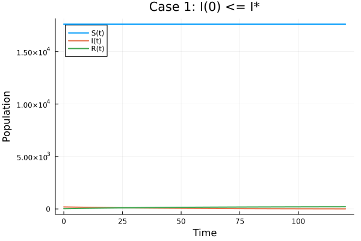

При изоляции число восприимчивых остаётся постоянным, а число инфицированных уменьшается за счёт выздоровления.

## Активное распространение

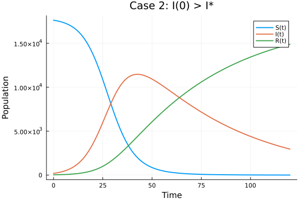

При активном распространении формируется эпидемическая волна.

## Эпидемический пик

Для базового значения $\alpha=10^{-5}$:

$$I_{\max}\approx11467,$$

пик достигается примерно при

$$t\approx42.6.$$

После пика число инфицированных начинает снижаться.

## Сравнение режимов

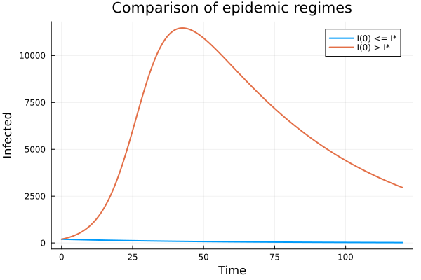

Изоляция приводит к постепенному затуханию инфекции, а активное распространение — к выраженной эпидемической волне.

# Параметрическое исследование

## Изменяемый параметр

Исследуется коэффициент заболеваемости:

$$\alpha\in
\{0.5\cdot10^{-5},\;
1.0\cdot10^{-5},\;
1.5\cdot10^{-5}\}.$$

Коэффициент выздоровления и начальные условия сохраняются.

## Влияние коэффициента заболеваемости

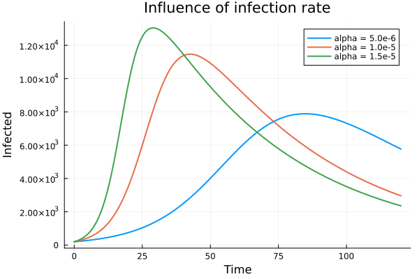

С ростом $\alpha$ максимум числа инфицированных увеличивается и достигается раньше.

## Численные результаты

| $\alpha$ | Пик инфицированных | Время пика |
| --- | --- | --- |
| $0.5\cdot10^{-5}$ | 7888 | 84.8 |
| $1.0\cdot10^{-5}$ | 11467 | 42.6 |
| $1.5\cdot10^{-5}$ | 13044 | 29.0 |

# Воспроизводимость

## Организация вычислений

- модель реализована на Julia;
- использован `DifferentialEquations.jl`;
- исходники оформлены в литературном стиле;
- сформированы Julia-скрипты;
- созданы и выполнены Jupyter Notebook;
- создана Quarto-документация;
- результаты сохранены в CSV и PNG.

# Результаты

## Основные результаты

- рассмотрены два режима развития эпидемии;
- построены графики $S(t)$, $I(t)$ и $R(t)$;
- найден эпидемический пик;
- проверено сохранение общей численности;
- исследовано влияние коэффициента заболеваемости;
- подтверждена воспроизводимость вычислений.

# Итоги

## Вывод

При изоляции заболевших инфекция постепенно затухает.

Если начинается активное распространение, формируется эпидемическая волна с выраженным максимумом числа инфицированных.

Увеличение коэффициента заболеваемости приводит к более высокому и более раннему эпидемическому пику.